# Risk Factor Analysis

## Outcome Variable

**Outcome Variable:** haz

## Predictor Variables

**Intervention Variable:** hhwealth_quart

**Adjustment Set:**

unadjusted

## Stratifying Variables

The analysis was stratified on these variable(s):

- agecat
- studyid
- country

## Data Summary

| agecat | studyid | country | hhwealth_quart | n_cell | n |
| --- | --- | --- | --- | --- | --- |
| Birth | ki0047075b-MAL-ED | BANGLADESH | Wealth Q4 | 56 | 213 |
| Birth | ki0047075b-MAL-ED | BANGLADESH | Wealth Q1 | 52 | 213 |
| Birth | ki0047075b-MAL-ED | BANGLADESH | Wealth Q2 | 51 | 213 |
| Birth | ki0047075b-MAL-ED | BANGLADESH | Wealth Q3 | 54 | 213 |
| Birth | ki0047075b-MAL-ED | BRAZIL | Wealth Q4 | 11 | 60 |
| Birth | ki0047075b-MAL-ED | BRAZIL | Wealth Q1 | 21 | 60 |
| Birth | ki0047075b-MAL-ED | BRAZIL | Wealth Q2 | 17 | 60 |
| Birth | ki0047075b-MAL-ED | BRAZIL | Wealth Q3 | 11 | 60 |
| Birth | ki0047075b-MAL-ED | INDIA | Wealth Q4 | 8 | 41 |
| Birth | ki0047075b-MAL-ED | INDIA | Wealth Q1 | 14 | 41 |
| Birth | ki0047075b-MAL-ED | INDIA | Wealth Q2 | 9 | 41 |
| Birth | ki0047075b-MAL-ED | INDIA | Wealth Q3 | 10 | 41 |
| Birth | ki0047075b-MAL-ED | NEPAL | Wealth Q4 | 6 | 26 |
| Birth | ki0047075b-MAL-ED | NEPAL | Wealth Q1 | 9 | 26 |
| Birth | ki0047075b-MAL-ED | NEPAL | Wealth Q2 | 3 | 26 |
| Birth | ki0047075b-MAL-ED | NEPAL | Wealth Q3 | 8 | 26 |
| Birth | ki0047075b-MAL-ED | PERU | Wealth Q4 | 54 | 215 |
| Birth | ki0047075b-MAL-ED | PERU | Wealth Q1 | 55 | 215 |
| Birth | ki0047075b-MAL-ED | PERU | Wealth Q2 | 54 | 215 |
| Birth | ki0047075b-MAL-ED | PERU | Wealth Q3 | 52 | 215 |
| Birth | ki0047075b-MAL-ED | SOUTH AFRICA | Wealth Q4 | 17 | 96 |
| Birth | ki0047075b-MAL-ED | SOUTH AFRICA | Wealth Q1 | 27 | 96 |
| Birth | ki0047075b-MAL-ED | SOUTH AFRICA | Wealth Q2 | 24 | 96 |
| Birth | ki0047075b-MAL-ED | SOUTH AFRICA | Wealth Q3 | 28 | 96 |
| Birth | ki0047075b-MAL-ED | TANZANIA, UNITED REPUBLIC OF | Wealth Q4 | 26 | 120 |
| Birth | ki0047075b-MAL-ED | TANZANIA, UNITED REPUBLIC OF | Wealth Q1 | 28 | 120 |
| Birth | ki0047075b-MAL-ED | TANZANIA, UNITED REPUBLIC OF | Wealth Q2 | 32 | 120 |
| Birth | ki0047075b-MAL-ED | TANZANIA, UNITED REPUBLIC OF | Wealth Q3 | 34 | 120 |
| Birth | ki1000108-CMC-V-BCS-2002 | INDIA | Wealth Q4 | 32 | 92 |
| Birth | ki1000108-CMC-V-BCS-2002 | INDIA | Wealth Q1 | 15 | 92 |

[output cut: 178 more lines]

The following strata were considered:

- agecat: 24 months, studyid: ki0047075b-MAL-ED, country: BANGLADESH
- agecat: 24 months, studyid: ki0047075b-MAL-ED, country: BRAZIL
- agecat: 24 months, studyid: ki0047075b-MAL-ED, country: INDIA
- agecat: 24 months, studyid: ki0047075b-MAL-ED, country: NEPAL
- agecat: 24 months, studyid: ki0047075b-MAL-ED, country: PERU
- agecat: 24 months, studyid: ki0047075b-MAL-ED, country: SOUTH AFRICA
- agecat: 24 months, studyid: ki0047075b-MAL-ED, country: TANZANIA, UNITED REPUBLIC OF
- agecat: 24 months, studyid: ki1000108-CMC-V-BCS-2002, country: INDIA
- agecat: 24 months, studyid: ki1000108-IRC, country: INDIA
- agecat: 24 months, studyid: ki1017093b-PROVIDE, country: BANGLADESH
- agecat: 24 months, studyid: ki1066203-TanzaniaChild2, country: TANZANIA, UNITED REPUBLIC OF
- agecat: 24 months, studyid: ki1113344-GMS-Nepal, country: NEPAL
- agecat: 24 months, studyid: ki1114097-CONTENT, country: PERU
- agecat: 24 months, studyid: ki1135781-COHORTS, country: GUATEMALA
- agecat: 24 months, studyid: ki1135781-COHORTS, country: PHILIPPINES
- agecat: 24 months, studyid: ki1148112-LCNI-5, country: MALAWI
- agecat: 24 months, studyid: kiGH5241-JiVitA-3, country: BANGLADESH
- agecat: 24 months, studyid: kiGH5241-JiVitA-4, country: BANGLADESH
- agecat: 6 months, studyid: ki0047075b-MAL-ED, country: BANGLADESH
- agecat: 6 months, studyid: ki0047075b-MAL-ED, country: BRAZIL
- agecat: 6 months, studyid: ki0047075b-MAL-ED, country: INDIA
- agecat: 6 months, studyid: ki0047075b-MAL-ED, country: NEPAL
- agecat: 6 months, studyid: ki0047075b-MAL-ED, country: PERU
- agecat: 6 months, studyid: ki0047075b-MAL-ED, country: SOUTH AFRICA
- agecat: 6 months, studyid: ki0047075b-MAL-ED, country: TANZANIA, UNITED REPUBLIC OF
- agecat: 6 months, studyid: ki1000108-CMC-V-BCS-2002, country: INDIA
- agecat: 6 months, studyid: ki1000108-IRC, country: INDIA
- agecat: 6 months, studyid: ki1017093b-PROVIDE, country: BANGLADESH
- agecat: 6 months, studyid: ki1066203-TanzaniaChild2, country: TANZANIA, UNITED REPUBLIC OF
- agecat: 6 months, studyid: ki1113344-GMS-Nepal, country: NEPAL
- agecat: 6 months, studyid: ki1114097-CONTENT, country: PERU
- agecat: 6 months, studyid: ki1135781-COHORTS, country: GUATEMALA
- agecat: 6 months, studyid: ki1135781-COHORTS, country: PHILIPPINES
- agecat: 6 months, studyid: ki1148112-LCNI-5, country: MALAWI
- agecat: 6 months, studyid: kiGH5241-JiVitA-3, country: BANGLADESH
- agecat: 6 months, studyid: kiGH5241-JiVitA-4, country: BANGLADESH
- agecat: Birth, studyid: ki0047075b-MAL-ED, country: BANGLADESH
- agecat: Birth, studyid: ki0047075b-MAL-ED, country: BRAZIL
- agecat: Birth, studyid: ki0047075b-MAL-ED, country: INDIA
- agecat: Birth, studyid: ki0047075b-MAL-ED, country: NEPAL
- agecat: Birth, studyid: ki0047075b-MAL-ED, country: PERU
- agecat: Birth, studyid: ki0047075b-MAL-ED, country: SOUTH AFRICA
- agecat: Birth, studyid: ki0047075b-MAL-ED, country: TANZANIA, UNITED REPUBLIC OF
- agecat: Birth, studyid: ki1000108-CMC-V-BCS-2002, country: INDIA
- agecat: Birth, studyid: ki1000108-IRC, country: INDIA
- agecat: Birth, studyid: ki1017093b-PROVIDE, country: BANGLADESH
- agecat: Birth, studyid: ki1113344-GMS-Nepal, country: NEPAL
- agecat: Birth, studyid: ki1114097-CONTENT, country: PERU
- agecat: Birth, studyid: ki1135781-COHORTS, country: GUATEMALA
- agecat: Birth, studyid: ki1135781-COHORTS, country: PHILIPPINES
- agecat: Birth, studyid: kiGH5241-JiVitA-3, country: BANGLADESH
- agecat: Birth, studyid: kiGH5241-JiVitA-4, country: BANGLADESH

### Dropped Strata

Some strata were dropped due to rare outcomes:

- agecat: Birth, studyid: ki0047075b-MAL-ED, country: NEPAL
- agecat: Birth, studyid: ki1114097-CONTENT, country: PERU
- agecat: 24 months, studyid: ki1066203-TanzaniaChild2, country: TANZANIA, UNITED REPUBLIC OF

## Methods Detail

We’re interested in the causal parameters $E[Y_a]$ for all values of $a \in \mathcal{A}$. These parameters represent the mean outcome if, possibly contrary to fact, we intervened to set all units to have $A=a$. Under the randomization and positivity assumptions, these are identified by the statistical parameters $\psi_a=E_W[E_{Y|A,W}(Y|A=a,W)]$. In addition, we’re interested in the mean of $Y$, $E[Y]$ under no intervention (the observed mean). We will estimate these parameters by using SuperLearner to fit the relevant likelihood factors – $E_{Y|A,W}(Y|A=a,W)$ and $p(A=a|W)$, and then updating our likelihood fit using a joint TMLE.

For unadjusted analyses ($W=\{\}$), initial likelihoods were estimated using Lrnr_glm to estimate the simple $E(Y|A)$ and Lrnr_mean to estimate $p(A)$. For adjusted analyses, a small library containing Lrnr_glmnet, Lrnr_xgboost, and Lrnr_mean was used.

Having estimated these parameters, we will then use the delta method to estimate relative risks and attributable risks relative to a prespecified baseline level of $A$.

# Results Detail

## Results Plots

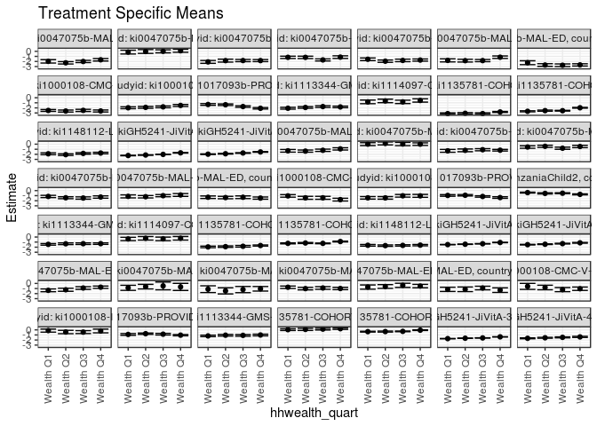

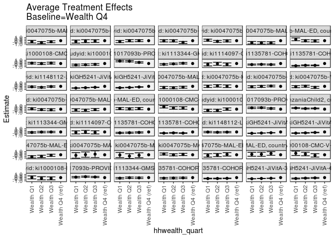

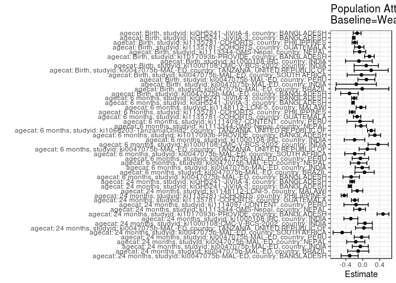

## Results Table

### Parameter: TSM

| agecat | studyid | country | intervention_level | baseline_level | estimate | ci_lower | ci_upper |
| --- | --- | --- | --- | --- | --- | --- | --- |
| Birth | ki0047075b-MAL-ED | BANGLADESH | Wealth Q4 | NA | -0.7389286 | -0.9642295 | -0.5136276 |
| Birth | ki0047075b-MAL-ED | BANGLADESH | Wealth Q1 | NA | -1.3615385 | -1.6354422 | -1.0876347 |
| Birth | ki0047075b-MAL-ED | BANGLADESH | Wealth Q2 | NA | -1.2470588 | -1.5462365 | -0.9478811 |
| Birth | ki0047075b-MAL-ED | BANGLADESH | Wealth Q3 | NA | -0.8985185 | -1.1593133 | -0.6377237 |
| Birth | ki0047075b-MAL-ED | BRAZIL | Wealth Q4 | NA | -0.6827273 | -1.3819847 | 0.0165301 |
| Birth | ki0047075b-MAL-ED | BRAZIL | Wealth Q1 | NA | -0.8657143 | -1.3681693 | -0.3632593 |
| Birth | ki0047075b-MAL-ED | BRAZIL | Wealth Q2 | NA | -0.6323529 | -1.0858683 | -0.1788376 |
| Birth | ki0047075b-MAL-ED | BRAZIL | Wealth Q3 | NA | -0.4854545 | -1.2577049 | 0.2867958 |
| Birth | ki0047075b-MAL-ED | INDIA | Wealth Q4 | NA | -1.0537500 | -1.5024873 | -0.6050127 |
| Birth | ki0047075b-MAL-ED | INDIA | Wealth Q1 | NA | -1.1307143 | -1.7957911 | -0.4656374 |
| Birth | ki0047075b-MAL-ED | INDIA | Wealth Q2 | NA | -1.4622222 | -2.0687425 | -0.8557019 |
| Birth | ki0047075b-MAL-ED | INDIA | Wealth Q3 | NA | -1.2070000 | -1.8208171 | -0.5931829 |
| Birth | ki0047075b-MAL-ED | PERU | Wealth Q4 | NA | -0.9998148 | -1.2246573 | -0.7749723 |
| Birth | ki0047075b-MAL-ED | PERU | Wealth Q1 | NA | -0.7503636 | -0.9872985 | -0.5134288 |
| Birth | ki0047075b-MAL-ED | PERU | Wealth Q2 | NA | -1.0168519 | -1.2644861 | -0.7692176 |
| Birth | ki0047075b-MAL-ED | PERU | Wealth Q3 | NA | -0.8917308 | -1.1536442 | -0.6298173 |
| Birth | ki0047075b-MAL-ED | SOUTH AFRICA | Wealth Q4 | NA | -0.5211765 | -0.8581919 | -0.1841611 |
| Birth | ki0047075b-MAL-ED | SOUTH AFRICA | Wealth Q1 | NA | -0.7133333 | -1.1310551 | -0.2956116 |
| Birth | ki0047075b-MAL-ED | SOUTH AFRICA | Wealth Q2 | NA | -0.6004167 | -0.9686266 | -0.2322068 |
| Birth | ki0047075b-MAL-ED | SOUTH AFRICA | Wealth Q3 | NA | -0.3750000 | -0.7881045 | 0.0381045 |
| Birth | ki0047075b-MAL-ED | TANZANIA, UNITED REPUBLIC OF | Wealth Q4 | NA | -1.3207692 | -1.7749094 | -0.8666290 |
| Birth | ki0047075b-MAL-ED | TANZANIA, UNITED REPUBLIC OF | Wealth Q1 | NA | -1.1639286 | -1.5791257 | -0.7487314 |
| Birth | ki0047075b-MAL-ED | TANZANIA, UNITED REPUBLIC OF | Wealth Q2 | NA | -1.1553125 | -1.6088534 | -0.7017716 |
| Birth | ki0047075b-MAL-ED | TANZANIA, UNITED REPUBLIC OF | Wealth Q3 | NA | -0.9058824 | -1.2610696 | -0.5506951 |
| Birth | ki1000108-CMC-V-BCS-2002 | INDIA | Wealth Q4 | NA | -1.0431250 | -1.3789911 | -0.7072589 |
| Birth | ki1000108-CMC-V-BCS-2002 | INDIA | Wealth Q1 | NA | -0.5800000 | -1.1756526 | 0.0156526 |
| Birth | ki1000108-CMC-V-BCS-2002 | INDIA | Wealth Q2 | NA | -0.7965000 | -1.2446483 | -0.3483517 |
| Birth | ki1000108-CMC-V-BCS-2002 | INDIA | Wealth Q3 | NA | -1.2168000 | -1.6233511 | -0.8102489 |
| Birth | ki1000108-IRC | INDIA | Wealth Q4 | NA | -0.2161538 | -0.5867320 | 0.1544243 |
| Birth | ki1000108-IRC | INDIA | Wealth Q1 | NA | -0.1436735 | -0.4437115 | 0.1563646 |

[output cut: 166 more lines]

### Parameter: E(Y)

| agecat | studyid | country | intervention_level | baseline_level | estimate | ci_lower | ci_upper |
| --- | --- | --- | --- | --- | --- | --- | --- |
| Birth | ki0047075b-MAL-ED | BANGLADESH | NA | NA | -1.0530516 | -1.1896058 | -0.9164975 |
| Birth | ki0047075b-MAL-ED | BRAZIL | NA | NA | -0.6963333 | -0.9881882 | -0.4044785 |
| Birth | ki0047075b-MAL-ED | INDIA | NA | NA | -1.2070732 | -1.5254820 | -0.8886644 |
| Birth | ki0047075b-MAL-ED | PERU | NA | NA | -0.9141395 | -1.0364098 | -0.7918693 |
| Birth | ki0047075b-MAL-ED | SOUTH AFRICA | NA | NA | -0.5523958 | -0.7550074 | -0.3497843 |
| Birth | ki0047075b-MAL-ED | TANZANIA, UNITED REPUBLIC OF | NA | NA | -1.1225000 | -1.3335666 | -0.9114334 |
| Birth | ki1000108-CMC-V-BCS-2002 | INDIA | NA | NA | -0.9611957 | -1.1776967 | -0.7446946 |
| Birth | ki1000108-IRC | INDIA | NA | NA | -0.3080412 | -0.4687931 | -0.1472894 |
| Birth | ki1017093b-PROVIDE | BANGLADESH | NA | NA | -0.8851020 | -0.9601332 | -0.8100709 |
| Birth | ki1113344-GMS-Nepal | NEPAL | NA | NA | -1.0851580 | -1.1651811 | -1.0051350 |
| Birth | ki1135781-COHORTS | GUATEMALA | NA | NA | 0.1452941 | 0.0610109 | 0.2295774 |
| Birth | ki1135781-COHORTS | PHILIPPINES | NA | NA | -0.2491505 | -0.2881717 | -0.2101294 |
| Birth | kiGH5241-JiVitA-3 | BANGLADESH | NA | NA | -1.5897094 | -1.6089856 | -1.5704331 |
| Birth | kiGH5241-JiVitA-4 | BANGLADESH | NA | NA | -1.5236135 | -1.5727559 | -1.4744711 |
| 6 months | ki0047075b-MAL-ED | BANGLADESH | NA | NA | -1.2026806 | -1.3203025 | -1.0850586 |
| 6 months | ki0047075b-MAL-ED | BRAZIL | NA | NA | 0.0475758 | -0.0963508 | 0.1915023 |
| 6 months | ki0047075b-MAL-ED | INDIA | NA | NA | -1.2070638 | -1.3255909 | -1.0885368 |
| 6 months | ki0047075b-MAL-ED | NEPAL | NA | NA | -0.5615819 | -0.6741832 | -0.4489807 |
| 6 months | ki0047075b-MAL-ED | PERU | NA | NA | -1.3248549 | -1.4336721 | -1.2160378 |
| 6 months | ki0047075b-MAL-ED | SOUTH AFRICA | NA | NA | -1.0547925 | -1.1843544 | -0.9252306 |
| 6 months | ki0047075b-MAL-ED | TANZANIA, UNITED REPUBLIC OF | NA | NA | -1.3687449 | -1.4907629 | -1.2467270 |
| 6 months | ki1000108-CMC-V-BCS-2002 | INDIA | NA | NA | -1.4234508 | -1.5645974 | -1.2823042 |
| 6 months | ki1000108-IRC | INDIA | NA | NA | -1.2344062 | -1.3658524 | -1.1029600 |
| 6 months | ki1017093b-PROVIDE | BANGLADESH | NA | NA | -1.0916915 | -1.1661176 | -1.0172654 |
| 6 months | ki1066203-TanzaniaChild2 | TANZANIA, UNITED REPUBLIC OF | NA | NA | -0.5442232 | -0.5932373 | -0.4952090 |
| 6 months | ki1113344-GMS-Nepal | NEPAL | NA | NA | -1.3508392 | -1.4290633 | -1.2726152 |
| 6 months | ki1114097-CONTENT | PERU | NA | NA | -0.3139217 | -0.4868486 | -0.1409948 |
| 6 months | ki1135781-COHORTS | GUATEMALA | NA | NA | -1.8112324 | -1.8807284 | -1.7417365 |
| 6 months | ki1135781-COHORTS | PHILIPPINES | NA | NA | -1.1405724 | -1.1824954 | -1.0986493 |
| 6 months | ki1148112-LCNI-5 | MALAWI | NA | NA | -1.6426961 | -1.7120603 | -1.5733318 |
| 6 months | kiGH5241-JiVitA-3 | BANGLADESH | NA | NA | -1.3132090 | -1.3363486 | -1.2900693 |
| 6 months | kiGH5241-JiVitA-4 | BANGLADESH | NA | NA | -1.3440477 | -1.3813060 | -1.3067894 |
| 24 months | ki0047075b-MAL-ED | BANGLADESH | NA | NA | -1.9783962 | -2.1050210 | -1.8517715 |
| 24 months | ki0047075b-MAL-ED | BRAZIL | NA | NA | 0.0061144 | -0.1625850 | 0.1748138 |
| 24 months | ki0047075b-MAL-ED | INDIA | NA | NA | -1.8861894 | -2.0110006 | -1.7613783 |
| 24 months | ki0047075b-MAL-ED | NEPAL | NA | NA | -1.3075877 | -1.4270718 | -1.1881037 |
| 24 months | ki0047075b-MAL-ED | PERU | NA | NA | -1.7524710 | -1.8736426 | -1.6312994 |
| 24 months | ki0047075b-MAL-ED | SOUTH AFRICA | NA | NA | -1.6450595 | -1.7797240 | -1.5103950 |
| 24 months | ki0047075b-MAL-ED | TANZANIA, UNITED REPUBLIC OF | NA | NA | -2.6455607 | -2.7807256 | -2.5103959 |
| 24 months | ki1000108-CMC-V-BCS-2002 | INDIA | NA | NA | -2.5588679 | -2.6583730 | -2.4593629 |
| 24 months | ki1000108-IRC | INDIA | NA | NA | -1.7987775 | -1.8923914 | -1.7051636 |
| 24 months | ki1017093b-PROVIDE | BANGLADESH | NA | NA | -1.6024221 | -1.6857420 | -1.5191023 |
| 24 months | ki1113344-GMS-Nepal | NEPAL | NA | NA | -1.8874180 | -1.9728588 | -1.8019773 |
| 24 months | ki1114097-CONTENT | PERU | NA | NA | -0.6962195 | -0.8674103 | -0.5250287 |
| 24 months | ki1135781-COHORTS | GUATEMALA | NA | NA | -2.9893430 | -3.0546993 | -2.9239867 |
| 24 months | ki1135781-COHORTS | PHILIPPINES | NA | NA | -2.4141145 | -2.4590818 | -2.3691473 |
| 24 months | ki1148112-LCNI-5 | MALAWI | NA | NA | -1.8822648 | -1.9637218 | -1.8008078 |
| 24 months | kiGH5241-JiVitA-3 | BANGLADESH | NA | NA | -2.0135591 | -2.0412422 | -1.9858759 |
| 24 months | kiGH5241-JiVitA-4 | BANGLADESH | NA | NA | -1.7803708 | -1.8158650 | -1.7448765 |

### Parameter: ATE

| agecat | studyid | country | intervention_level | baseline_level | estimate | ci_lower | ci_upper |
| --- | --- | --- | --- | --- | --- | --- | --- |
| Birth | ki0047075b-MAL-ED | BANGLADESH | Wealth Q4 | Wealth Q4 | 0.0000000 | 0.0000000 | 0.0000000 |
| Birth | ki0047075b-MAL-ED | BANGLADESH | Wealth Q1 | Wealth Q4 | -0.6226099 | -0.9772700 | -0.2679498 |
| Birth | ki0047075b-MAL-ED | BANGLADESH | Wealth Q2 | Wealth Q4 | -0.5081303 | -0.8826537 | -0.1336068 |
| Birth | ki0047075b-MAL-ED | BANGLADESH | Wealth Q3 | Wealth Q4 | -0.1595899 | -0.5042267 | 0.1850468 |
| Birth | ki0047075b-MAL-ED | BRAZIL | Wealth Q4 | Wealth Q4 | 0.0000000 | 0.0000000 | 0.0000000 |
| Birth | ki0047075b-MAL-ED | BRAZIL | Wealth Q1 | Wealth Q4 | -0.1829870 | -1.0440456 | 0.6780716 |
| Birth | ki0047075b-MAL-ED | BRAZIL | Wealth Q2 | Wealth Q4 | 0.0503743 | -0.7830746 | 0.8838232 |
| Birth | ki0047075b-MAL-ED | BRAZIL | Wealth Q3 | Wealth Q4 | 0.1972727 | -0.8445197 | 1.2390652 |
| Birth | ki0047075b-MAL-ED | INDIA | Wealth Q4 | Wealth Q4 | 0.0000000 | 0.0000000 | 0.0000000 |
| Birth | ki0047075b-MAL-ED | INDIA | Wealth Q1 | Wealth Q4 | -0.0769643 | -0.8792687 | 0.7253402 |
| Birth | ki0047075b-MAL-ED | INDIA | Wealth Q2 | Wealth Q4 | -0.4084722 | -1.1629469 | 0.3460025 |
| Birth | ki0047075b-MAL-ED | INDIA | Wealth Q3 | Wealth Q4 | -0.1532500 | -0.9136030 | 0.6071030 |
| Birth | ki0047075b-MAL-ED | PERU | Wealth Q4 | Wealth Q4 | 0.0000000 | 0.0000000 | 0.0000000 |
| Birth | ki0047075b-MAL-ED | PERU | Wealth Q1 | Wealth Q4 | 0.2494512 | -0.0771867 | 0.5760890 |
| Birth | ki0047075b-MAL-ED | PERU | Wealth Q2 | Wealth Q4 | -0.0170370 | -0.3515171 | 0.3174430 |
| Birth | ki0047075b-MAL-ED | PERU | Wealth Q3 | Wealth Q4 | 0.1080840 | -0.2371011 | 0.4532692 |
| Birth | ki0047075b-MAL-ED | SOUTH AFRICA | Wealth Q4 | Wealth Q4 | 0.0000000 | 0.0000000 | 0.0000000 |
| Birth | ki0047075b-MAL-ED | SOUTH AFRICA | Wealth Q1 | Wealth Q4 | -0.1921569 | -0.7288792 | 0.3445654 |
| Birth | ki0047075b-MAL-ED | SOUTH AFRICA | Wealth Q2 | Wealth Q4 | -0.0792402 | -0.5783974 | 0.4199170 |
| Birth | ki0047075b-MAL-ED | SOUTH AFRICA | Wealth Q3 | Wealth Q4 | 0.1461765 | -0.3869602 | 0.6793131 |
| Birth | ki0047075b-MAL-ED | TANZANIA, UNITED REPUBLIC OF | Wealth Q4 | Wealth Q4 | 0.0000000 | 0.0000000 | 0.0000000 |
| Birth | ki0047075b-MAL-ED | TANZANIA, UNITED REPUBLIC OF | Wealth Q1 | Wealth Q4 | 0.1568407 | -0.4584902 | 0.7721715 |
| Birth | ki0047075b-MAL-ED | TANZANIA, UNITED REPUBLIC OF | Wealth Q2 | Wealth Q4 | 0.1654567 | -0.4763709 | 0.8072844 |
| Birth | ki0047075b-MAL-ED | TANZANIA, UNITED REPUBLIC OF | Wealth Q3 | Wealth Q4 | 0.4148869 | -0.1616557 | 0.9914294 |
| Birth | ki1000108-CMC-V-BCS-2002 | INDIA | Wealth Q4 | Wealth Q4 | 0.0000000 | 0.0000000 | 0.0000000 |
| Birth | ki1000108-CMC-V-BCS-2002 | INDIA | Wealth Q1 | Wealth Q4 | 0.4631250 | -0.2206937 | 1.1469437 |
| Birth | ki1000108-CMC-V-BCS-2002 | INDIA | Wealth Q2 | Wealth Q4 | 0.2466250 | -0.3134133 | 0.8066633 |
| Birth | ki1000108-CMC-V-BCS-2002 | INDIA | Wealth Q3 | Wealth Q4 | -0.1736750 | -0.7010172 | 0.3536672 |
| Birth | ki1000108-IRC | INDIA | Wealth Q4 | Wealth Q4 | 0.0000000 | 0.0000000 | 0.0000000 |
| Birth | ki1000108-IRC | INDIA | Wealth Q1 | Wealth Q4 | 0.0724804 | -0.4043330 | 0.5492937 |

[output cut: 166 more lines]

### Parameter: PAR

| agecat | studyid | country | intervention_level | baseline_level | estimate | ci_lower | ci_upper |
| --- | --- | --- | --- | --- | --- | --- | --- |
| Birth | ki0047075b-MAL-ED | BANGLADESH | Wealth Q4 | NA | -0.3141231 | -0.5208029 | -0.1074432 |
| Birth | ki0047075b-MAL-ED | BRAZIL | Wealth Q4 | NA | -0.0136061 | -0.6419805 | 0.6147684 |
| Birth | ki0047075b-MAL-ED | INDIA | Wealth Q4 | NA | -0.1533232 | -0.6267868 | 0.3201405 |
| Birth | ki0047075b-MAL-ED | PERU | Wealth Q4 | NA | 0.0856753 | -0.1145983 | 0.2859489 |
| Birth | ki0047075b-MAL-ED | SOUTH AFRICA | Wealth Q4 | NA | -0.0312194 | -0.3694571 | 0.3070184 |
| Birth | ki0047075b-MAL-ED | TANZANIA, UNITED REPUBLIC OF | Wealth Q4 | NA | 0.1982692 | -0.2035022 | 0.6000407 |
| Birth | ki1000108-CMC-V-BCS-2002 | INDIA | Wealth Q4 | NA | 0.0819293 | -0.2030355 | 0.3668942 |
| Birth | ki1000108-IRC | INDIA | Wealth Q4 | NA | -0.0918874 | -0.4061365 | 0.2223617 |
| Birth | ki1017093b-PROVIDE | BANGLADESH | Wealth Q4 | NA | 0.1563374 | 0.0416611 | 0.2710136 |
| Birth | ki1113344-GMS-Nepal | NEPAL | Wealth Q4 | NA | -0.0720945 | -0.2137997 | 0.0696108 |
| Birth | ki1135781-COHORTS | GUATEMALA | Wealth Q4 | NA | -0.0832724 | -0.1951957 | 0.0286509 |
| Birth | ki1135781-COHORTS | PHILIPPINES | Wealth Q4 | NA | -0.1905163 | -0.2523107 | -0.1287220 |
| Birth | kiGH5241-JiVitA-3 | BANGLADESH | Wealth Q4 | NA | -0.2120853 | -0.2409396 | -0.1832309 |
| Birth | kiGH5241-JiVitA-4 | BANGLADESH | Wealth Q4 | NA | -0.1331395 | -0.2259606 | -0.0403184 |
| 6 months | ki0047075b-MAL-ED | BANGLADESH | Wealth Q4 | NA | -0.2730357 | -0.4677386 | -0.0783329 |
| 6 months | ki0047075b-MAL-ED | BRAZIL | Wealth Q4 | NA | 0.0426387 | -0.1846829 | 0.2699602 |
| 6 months | ki0047075b-MAL-ED | INDIA | Wealth Q4 | NA | -0.0148322 | -0.1799501 | 0.1502857 |
| 6 months | ki0047075b-MAL-ED | NEPAL | Wealth Q4 | NA | -0.0977966 | -0.2930216 | 0.0974284 |
| 6 months | ki0047075b-MAL-ED | PERU | Wealth Q4 | NA | -0.0558997 | -0.2508217 | 0.1390223 |
| 6 months | ki0047075b-MAL-ED | SOUTH AFRICA | Wealth Q4 | NA | -0.1905721 | -0.4259567 | 0.0448125 |
| 6 months | ki0047075b-MAL-ED | TANZANIA, UNITED REPUBLIC OF | Wealth Q4 | NA | 0.1081863 | -0.0870511 | 0.3034237 |
| 6 months | ki1000108-CMC-V-BCS-2002 | INDIA | Wealth Q4 | NA | 0.3622230 | 0.1243626 | 0.6000834 |
| 6 months | ki1000108-IRC | INDIA | Wealth Q4 | NA | -0.1943389 | -0.4364239 | 0.0477461 |
| 6 months | ki1017093b-PROVIDE | BANGLADESH | Wealth Q4 | NA | 0.2834320 | 0.1467054 | 0.4201585 |
| 6 months | ki1066203-TanzaniaChild2 | TANZANIA, UNITED REPUBLIC OF | Wealth Q4 | NA | 0.1995086 | 0.1131602 | 0.2858569 |
| 6 months | ki1113344-GMS-Nepal | NEPAL | Wealth Q4 | NA | -0.0429702 | -0.1718520 | 0.0859116 |
| 6 months | ki1114097-CONTENT | PERU | Wealth Q4 | NA | -0.0654826 | -0.3727333 | 0.2417681 |
| 6 months | ki1135781-COHORTS | GUATEMALA | Wealth Q4 | NA | -0.1336513 | -0.2218265 | -0.0454761 |
| 6 months | ki1135781-COHORTS | PHILIPPINES | Wealth Q4 | NA | -0.2502628 | -0.3186550 | -0.1818707 |
| 6 months | ki1148112-LCNI-5 | MALAWI | Wealth Q4 | NA | -0.0432030 | -0.1566832 | 0.0702772 |
| 6 months | kiGH5241-JiVitA-3 | BANGLADESH | Wealth Q4 | NA | -0.2291560 | -0.2576091 | -0.2007029 |
| 6 months | kiGH5241-JiVitA-4 | BANGLADESH | Wealth Q4 | NA | -0.2021711 | -0.2641778 | -0.1401644 |
| 24 months | ki0047075b-MAL-ED | BANGLADESH | Wealth Q4 | NA | -0.3098716 | -0.5106732 | -0.1090700 |
| 24 months | ki0047075b-MAL-ED | BRAZIL | Wealth Q4 | NA | -0.1075648 | -0.3568874 | 0.1417577 |
| 24 months | ki0047075b-MAL-ED | INDIA | Wealth Q4 | NA | -0.0588165 | -0.2483577 | 0.1307246 |
| 24 months | ki0047075b-MAL-ED | NEPAL | Wealth Q4 | NA | -0.1652148 | -0.3792540 | 0.0488243 |
| 24 months | ki0047075b-MAL-ED | PERU | Wealth Q4 | NA | -0.0277787 | -0.2023980 | 0.1468407 |
| 24 months | ki0047075b-MAL-ED | SOUTH AFRICA | Wealth Q4 | NA | -0.4854563 | -0.7000642 | -0.2708485 |
| 24 months | ki0047075b-MAL-ED | TANZANIA, UNITED REPUBLIC OF | Wealth Q4 | NA | 0.0272964 | -0.1698522 | 0.2244450 |
| 24 months | ki1000108-CMC-V-BCS-2002 | INDIA | Wealth Q4 | NA | 0.0524796 | -0.1186695 | 0.2236287 |
| 24 months | ki1000108-IRC | INDIA | Wealth Q4 | NA | -0.2810608 | -0.4456050 | -0.1165167 |
| 24 months | ki1017093b-PROVIDE | BANGLADESH | Wealth Q4 | NA | 0.4770407 | 0.3379290 | 0.6161523 |
| 24 months | ki1113344-GMS-Nepal | NEPAL | Wealth Q4 | NA | -0.0742998 | -0.2131637 | 0.0645642 |
| 24 months | ki1114097-CONTENT | PERU | Wealth Q4 | NA | -0.1579268 | -0.4448160 | 0.1289624 |
| 24 months | ki1135781-COHORTS | GUATEMALA | Wealth Q4 | NA | -0.1883977 | -0.2685050 | -0.1082904 |
| 24 months | ki1135781-COHORTS | PHILIPPINES | Wealth Q4 | NA | -0.4380535 | -0.5084470 | -0.3676600 |
| 24 months | ki1148112-LCNI-5 | MALAWI | Wealth Q4 | NA | -0.1303273 | -0.2597428 | -0.0009119 |
| 24 months | kiGH5241-JiVitA-3 | BANGLADESH | Wealth Q4 | NA | -0.3036014 | -0.3438509 | -0.2633518 |
| 24 months | kiGH5241-JiVitA-4 | BANGLADESH | Wealth Q4 | NA | -0.2486524 | -0.3040467 | -0.1932581 |